# Exploration of Red Wine Composition

Fernando Maletski

This project aims to shed a light on how the chemical composition of a red wine affect it’s quality, measured by a median sensory score from at least 3 wine tasting experts.

#### The dataset was provided by:

P. Cortez, A. Cerdeira, F. Almeida, T. Matos and J. Reis. Modeling wine preferences by data mining from physicochemical properties. In Decision Support Systems, Elsevier, 47(4):547-553. ISSN: 0167-9236.

Available at: [@Elsevier] http://dx.doi.org/10.1016/j.dss.2009.05.016 [Pre-press (pdf)] http://www3.dsi.uminho.pt/pcortez/winequality09.pdf [bib] http://www3.dsi.uminho.pt/pcortez/dss09.bib

# Univariate Plots Section

Here we’ll be taking a look at the various variables in the dataset, with a brief description, and histograms showing the count of data points.

### Dataset Dimentions

```
## [1] 1599   12
```

We have 1599 data points with 12 variables.

### Dataset Structure

```
## 'data.frame':    1599 obs. of  12 variables:
##  $ fixed.acidity       : num  7.4 7.8 7.8 11.2 7.4 7.4 7.9 7.3 7.8 7.5 ...
##  $ volatile.acidity    : num  0.7 0.88 0.76 0.28 0.7 0.66 0.6 0.65 0.58 0.5 ...
##  $ citric.acid         : num  0 0 0.04 0.56 0 0 0.06 0 0.02 0.36 ...
##  $ residual.sugar      : num  1.9 2.6 2.3 1.9 1.9 1.8 1.6 1.2 2 6.1 ...
##  $ chlorides           : num  0.076 0.098 0.092 0.075 0.076 0.075 0.069 0.065 0.073 0.071 ...
##  $ free.sulfur.dioxide : num  11 25 15 17 11 13 15 15 9 17 ...
##  $ total.sulfur.dioxide: num  34 67 54 60 34 40 59 21 18 102 ...
##  $ density             : num  0.998 0.997 0.997 0.998 0.998 ...
##  $ pH                  : num  3.51 3.2 3.26 3.16 3.51 3.51 3.3 3.39 3.36 3.35 ...
##  $ sulphates           : num  0.56 0.68 0.65 0.58 0.56 0.56 0.46 0.47 0.57 0.8 ...
##  $ alcohol             : num  9.4 9.8 9.8 9.8 9.4 9.4 9.4 10 9.5 10.5 ...
##  $ quality             : int  5 5 5 6 5 5 5 7 7 5 ...
```

### Dataset Summary

```
##  fixed.acidity   volatile.acidity  citric.acid    residual.sugar
##  Min.   : 4.60   Min.   :0.1200   Min.   :0.000   Min.   : 0.900
##  1st Qu.: 7.10   1st Qu.:0.3900   1st Qu.:0.090   1st Qu.: 1.900
##  Median : 7.90   Median :0.5200   Median :0.260   Median : 2.200
##  Mean   : 8.32   Mean   :0.5278   Mean   :0.271   Mean   : 2.539
##  3rd Qu.: 9.20   3rd Qu.:0.6400   3rd Qu.:0.420   3rd Qu.: 2.600
##  Max.   :15.90   Max.   :1.5800   Max.   :1.000   Max.   :15.500
##    chlorides       free.sulfur.dioxide total.sulfur.dioxide
##  Min.   :0.01200   Min.   : 1.00       Min.   :  6.00
##  1st Qu.:0.07000   1st Qu.: 7.00       1st Qu.: 22.00
##  Median :0.07900   Median :14.00       Median : 38.00
##  Mean   :0.08747   Mean   :15.87       Mean   : 46.47
##  3rd Qu.:0.09000   3rd Qu.:21.00       3rd Qu.: 62.00
##  Max.   :0.61100   Max.   :72.00       Max.   :289.00
##     density             pH          sulphates         alcohol
##  Min.   :0.9901   Min.   :2.740   Min.   :0.3300   Min.   : 8.40
##  1st Qu.:0.9956   1st Qu.:3.210   1st Qu.:0.5500   1st Qu.: 9.50
##  Median :0.9968   Median :3.310   Median :0.6200   Median :10.20
##  Mean   :0.9967   Mean   :3.311   Mean   :0.6581   Mean   :10.42
##  3rd Qu.:0.9978   3rd Qu.:3.400   3rd Qu.:0.7300   3rd Qu.:11.10
##  Max.   :1.0037   Max.   :4.010   Max.   :2.0000   Max.   :14.90
##     quality
##  Min.   :3.000
##  1st Qu.:5.000
##  Median :6.000
##  Mean   :5.636
##  3rd Qu.:6.000
##  Max.   :8.000
```

### Output variable, quality

Quality was measured by at least 3 wine experts who graded each wine using a score that goes from 0 (very bad) to 10 (very excellent). The value present in the dataset is the median of those scores.

As we can see in the summary above, the quality scores in the dataset actually ranges from 3 to 8.

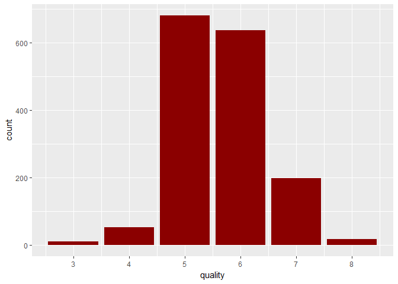

As we can see in the summary above and on the plot, the quality scores in the dataset actually ranges from 3 to 8, normally distributed, with most scores ranging from 5 to 7, there is no decimal value.

### Fixed Acidity

The quantity, in grams per liter (g/dm^3), of nonvolatile acids.

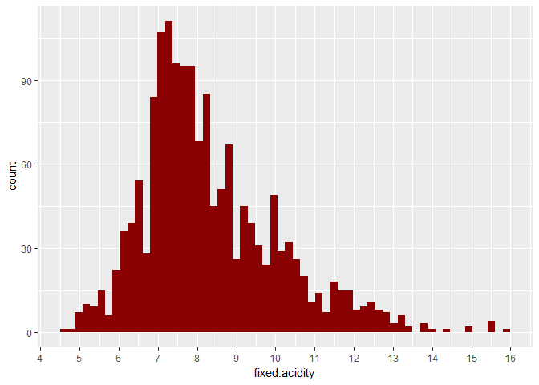

Again we have a normally distributed variable, but this time, there’s a few outliers, with a mode at around 7.0.

#### Outliers

There are many ways to detect ouliers, throughout this project, we’ll the boxplot definition:

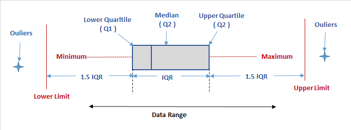

Will be considered outliers values above Q2 + 1.5 IQR and below Q1 - 1.5 IQR. However, I don’t think removing them is wise, because the dataset is already limited if we take into consideration the fact that there are very few wines of above or below average quality. The outliers may be the reason why a wine distinguishes itself, for better or worse.

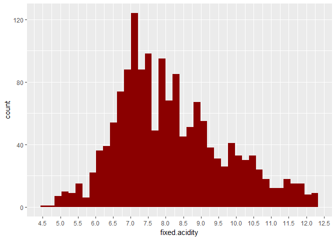

Removing outliers and ajusting the bins brings no new information. For this variable, values below 4.5 and 12.25 are considered outliers.

### Volatile Acidity

The amount of acetic acid, in grams per liter (g/dm^3). This acid in high quantities lead to the unpleasant, vinegar taste found in some wines.

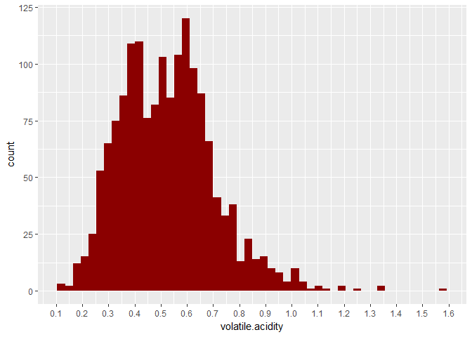

Most wines have between 0.3 and 0.8 grams per liter, with very few above the 1.0 mark. It’s a bi modal normal distribution with 0.4 and 0.6 as modes.

#### Outliers

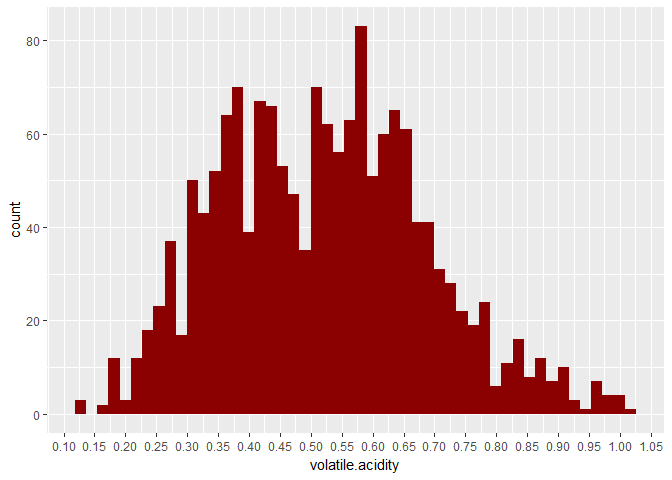

Values above 1.025 are considered outliers.

### Citric Acid

Measured in grams per liter (g/dm^3). Present in small quantities, citric acid adds a “freshness” and citric flavor to the wine.

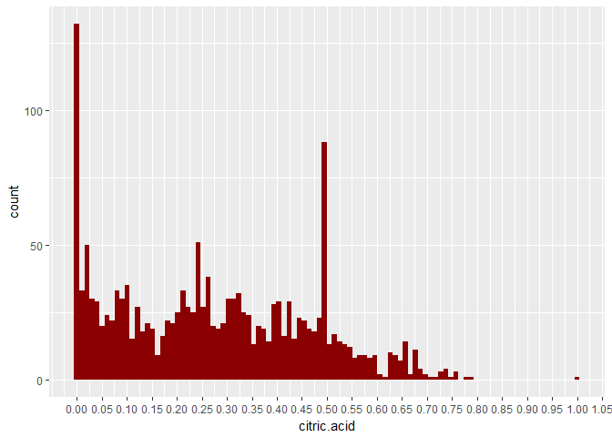

We have a pretty even, slightly positively skewed distribution. Is of note, that there’s 2 clear spikes, at 0 and around 0.5 grams per liter.

#### Outliers

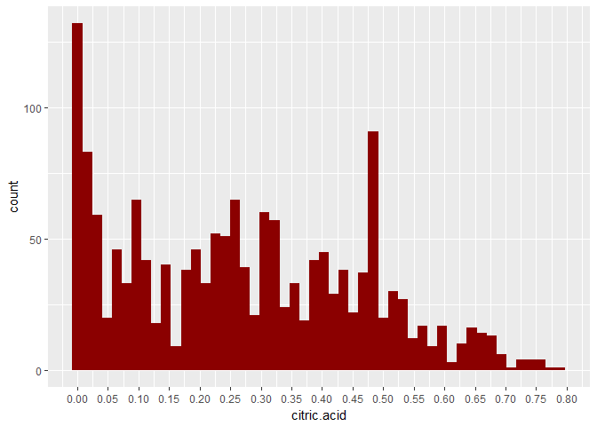

Values above 0.8 are outliers. No surprises here.

### Residual Sugar

The quantity of sugar remaining after the fermentation stops, in grams per liter (g/dm^3). It’s rare to find wines with less than 1 g/liter and above 45 they are considered “sweet”.

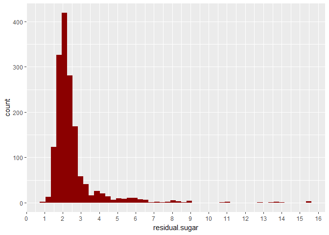

Most wines have between 1 and 3 grams per liter. We have no “sweet” wines in our dataset.

#### Outliers

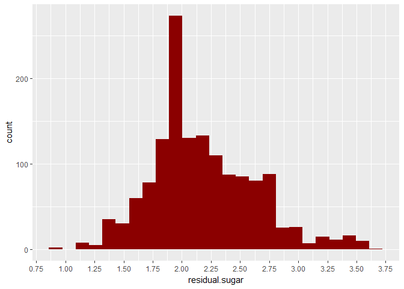

There are many outliers for this feature, values above 3.75. Removing them or using descriptive statistics may be necessary to create a profile by quality for Residual Sugar.

### Chlorides

The amount of salt (sodium chloride), in grams per liter (g/dm^3).

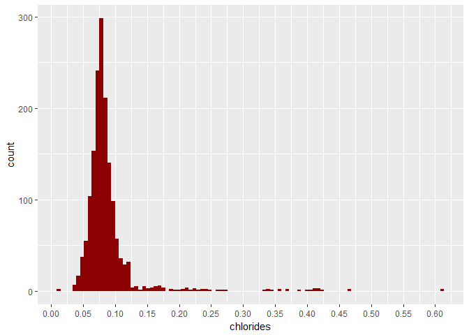

Very few observations below 0.025 and above 0.125 grams per liter, with many significant outliers.

#### Outliers

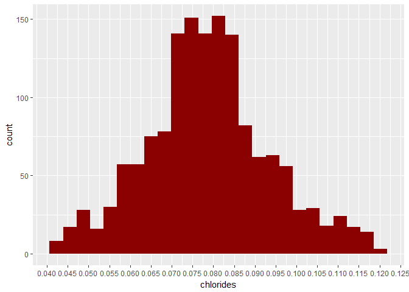

Discarding the outliers, values above 1.120 or below 0.04 we have a normal distribution with a mode at 0.0775.

We may encounter the same problems described in the Residual Sugar variable section.

### Free Sulfur Dioxide

Free form SO2 exists in equilibrium between molecular SO2 (as a dissolved gas) and bisulfite ion. Prevents microbial growth and the oxidation of wine. But concentrations of over 50 ppm (roughly 50 mg/L, considering the density the same as water) becomes evident in the taste and the bouquet (smell) of the wine.

Measured in milligrams per liter (mg/dm^3).

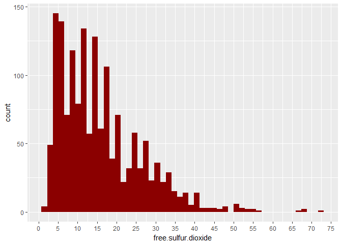

#### Outliers

Makes no sense to remove outliers because of the ‘taste threshold’ described above.

### Total Sulfur Dioxide

The total amount of SO2, free and bound in milligrams per liter (mg/dm^3). The impact on the score should be less evident than its free counterpart.

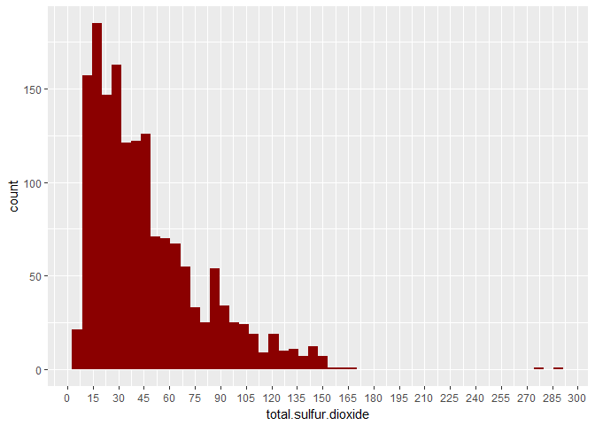

#### Outliers

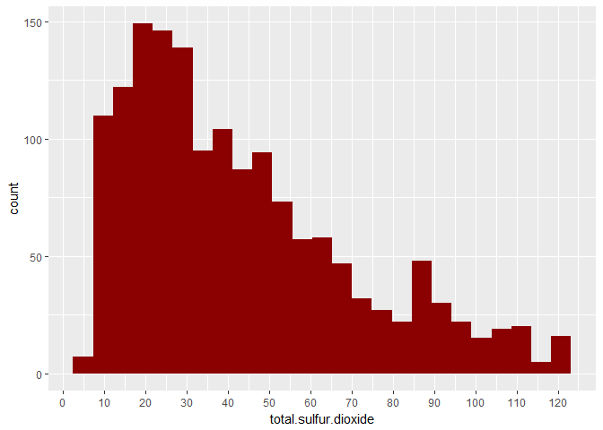

Values above 120 are outliers.

### Density

The density of the wine may be closer to that of water (1 kg/L) depending on the alcohol and sugar content. This variable is measured in kilograms per liter (kg/L). Sugar tends to make the wine more dense and alcohol less dense.

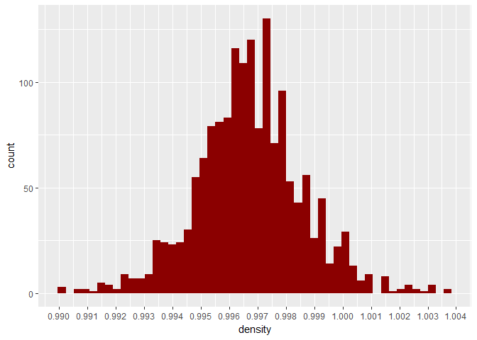

The majority of wines are a little bit less dense than water (kg/L), but there is a few exceptions.

#### Outliers

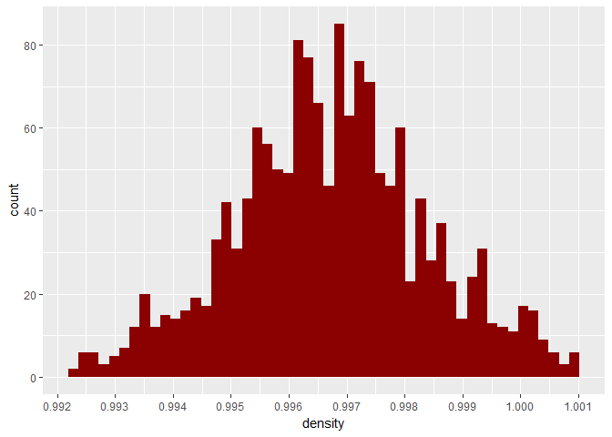

Values below 0.992 and above 1.001 are outliers.

### Free Sulfur Dioxide (ppm)

Multiplying Free Sulfur Dioxide by density converts it to ppm so we can accurately compare it with the 50 ppm threshold from the dataset documentation:

```
##    Min. 1st Qu.  Median    Mean 3rd Qu.    Max.
##  0.9973  6.9910 13.9100 15.8200 20.9900 71.8000
```

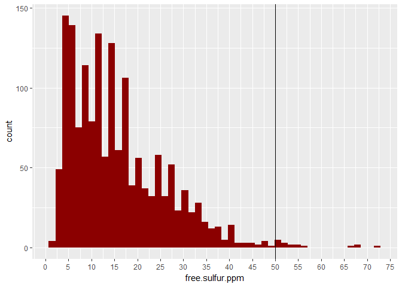

As expected, the plot is very similar, but using the correct units is important to not make hasty assumptions.

#### Outliers

Makes no sense to remove outliers here.

### pH

pH is a very well known numeric scale to specify the acidity or basicity of a liquid. It usually ranges from 0 (very acidic) to 14 (very basic), but can exceed those values on extreme cases.

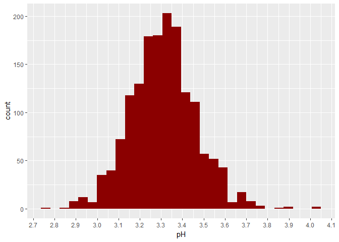

We have a nice normal distribution with most wines between 3 and 3.6 on the pH scale.

#### Outliers

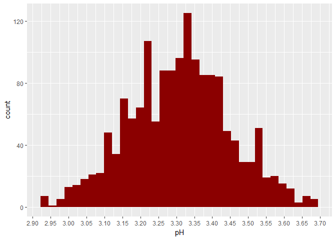

Values below 2.925 and above 3.70 are outliers.

### Sulphates

Sulphates are wine additives that contribute to the sulfur dioxide (SO2) levels. SO2 is necessary because it acts as an antimicrobial and antioxidant, preserving the wine. This variable is in grams per liter (g/dm3)

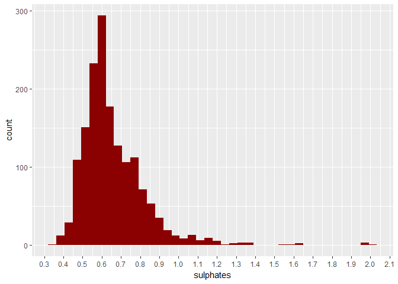

Very few wines exceed the 1.2 g/L mark, we have significan outliers here.

#### Outliers

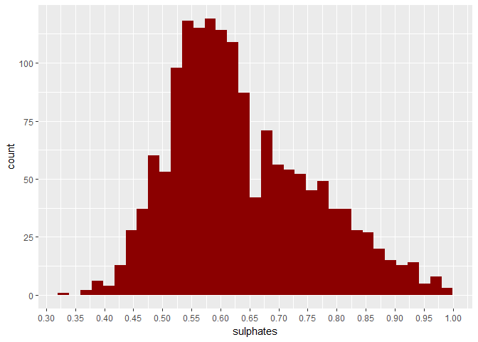

Removing the outliers, it becomes evident that this variable is approximately normally distributed with the mode at 0.6 g/L.

### Alcohol

And lastly, alcohol content in percent by volume.

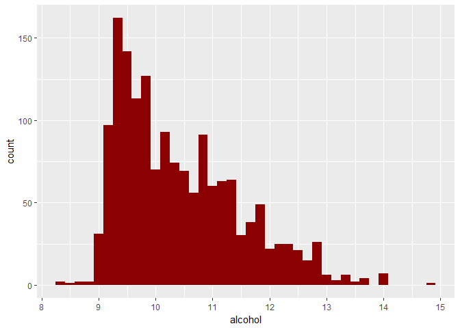

#### Outliers

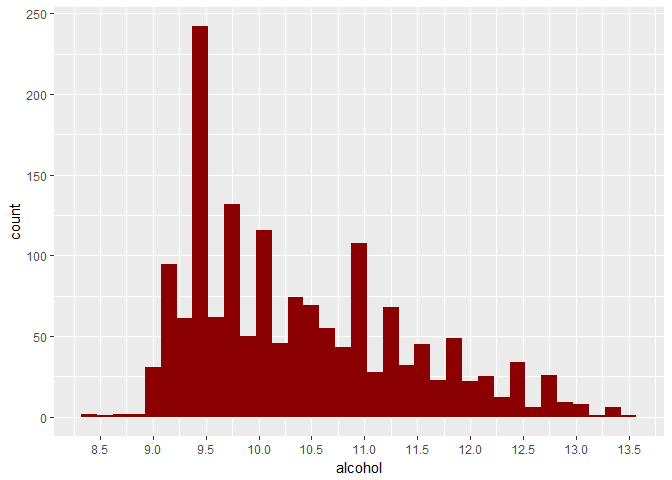

Values above 13.5 are outliers.

### Wine Profile by Quality

As we have very few wines of the best (18) and worst (10) quality available, it makes sense to expand the bins to include more scores:

```
##
##   3   4   5   6   7   8
##  10  53 681 638 199  18
```

If we isolate the best (quality = 7 and 8) and worst (quality = 3 and 4) wines in our dataset we can have three profiles of wines:

- Worst wines: Quality = 3 and 4
- Average wines: Quality = 5 and 6
- Best wines: Quality = 7 and 8

```
##
##   worst average    best
##      63    1319     217
```

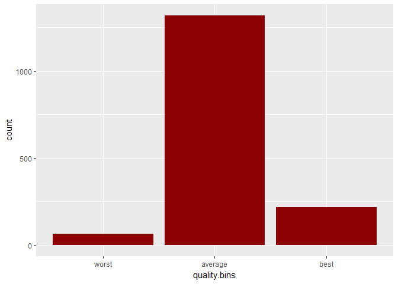

Most wines are average, but now we have more wines in each bin.

A radar plot using those profiles can help us identify trends in the data. We’ll be using the ppm (parts per million) version of the ‘Free Sulfur Dioxide’ variable:

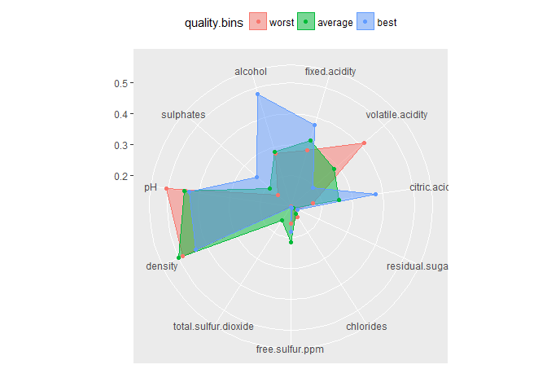

As we have significant outliers in the following variables: sulphates, total sulfur dioxide, chlorides and residual sugar, taking the mean of all the variables in the groups and normalizing the results to between 0.5 ,for the lowest value, and 1.0, for the highest, can further help identifying the trends. It is important to say that doing so we lose some dimensionality information, but trends tend to be clearer:

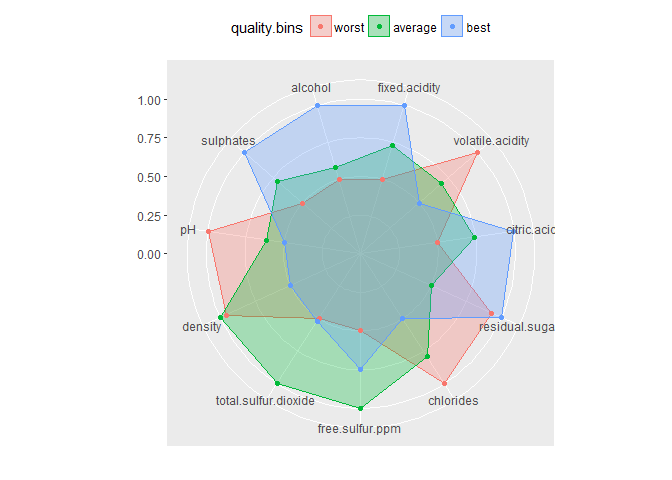

***

# Univariate Analysis

### What is the structure of your dataset?

There are 1599 red wines in the dataset with 12 variables, one of them, quality is the output variable, in other words, we will be trying to determine which variables have an effect, and which effect it is, in the quality of the wine. Preliminary analysis has the variables split in three different groups:

- Positive effect - Variables that tend to increase the quality of the wines as they increase, to a limit of course (we will study the outliers later on).
  - Fixed Acidity
  - Citric Acid
  - Sulphates
  - Alcohol
- Negative effect - Variables that tend to have the opposite effect, decreasing the quality of the wine as they increase:
  - Volatile Acidity
  - Chlorides
  - pH
- Undetermined effect - Variables that we can’t classify still, maybe they have a more complicated relationship (for example, increasing the quality up until a certain value), further investigation is necessary:
  - Residual Sugar
  - Free Sulfur Dioxide (ppm)
  - Total Sulfur Dioxide
  - Density

Further investigation is necessary to confirm these hypothesis and to better understand the “Undetermined effect” variables.

Other observations:

- There is no “perfect wine”, quality actually ranges between 3 and 8, with most wines scoring 5 and 6 (1319).
- Four variables have significant outliers:
  - Sulphates
  - Total Sulfur Dioxide
  - Chlorides
  - Residual Sugar
- With the exception of “Citric Acid”, “Free Sulfur Dioxide”, “Total Sulfur Dioxide” and “Alcohol”, the variables tend to be normally distributed, or pretty close to it.
- “Free Sulfur Dioxide”, “Total Sulfur Dioxide” and “Alcohol” are positively skewed.
- “Citric Acid” have a pretty even distribution, a bit positively skewed. There is 2 pronounced spikes at 0 and around 0.5.

### What is/are the main feature(s) of interest in your dataset?

The main feature is quality. This exploration objective is to determine how and which other variables have an effect on it. Choosing the right variables, i suspect a linear model could be created to predict the quality based on the remaining variables.

### What other features in the dataset do you think will help support your investigation into your feature(s) of interest?

As stated in the first question, all the variables seems to have an effect on quality, albeit differently, there are variables with positive, negative and yet undetermined effects. Further investigation is necessary to confirm this hypothesis and to clarify the undetermined variables.

One point of interest that needs a deeper analysis is the relationship between variables. For example, in the documentation of the dataset is stated that sugar and alcohol have an effect on density, so it is important in investigate if density can be treated as an independent variable as is necessary to use it on a linear model (regression). The same can be said to sulphates, free and total sulfur dioxide.

### Did you create any new variables from existing variables in the dataset?

Two: * The first, Free Sulfur Dioxide (ppm), is the result of the multiplication of two other variables, free sulfur dioxide (mg/L) and density. I created this variable because there was mentioned in the dataset documentation that at levels above 50 ppm, free SO2 becomes evident in the taste and smell of the wine, and I’ll be using it, instead of the mg/L version, for the rest of the analysis.

- The second one is more of a classification of quality then a new variable. It has three possible values:
  - worst: Quality = 3 and 4
  - average: Quality = 5 and 6
  - best: Quality = 7 and 8

### Of the features you investigated, were there any unusual distributions? Did you perform any operations on the data to tidy, adjust, or change the form of the data? If so, why did you do this?

There was two variable with such pronounced outliers that I had to zoom in the plot to have a better understanding of them: residual sugar and chlorides. You could say that citric acid has a weird distribution, being somewhat even and with two spikes, but I didn’t need to perform any transformations to better understand it.

# Bivariate Plots Section

Here we’ll be looking into the relationship between the variables, and dig deeper into the relationship of each one of them and the quality.

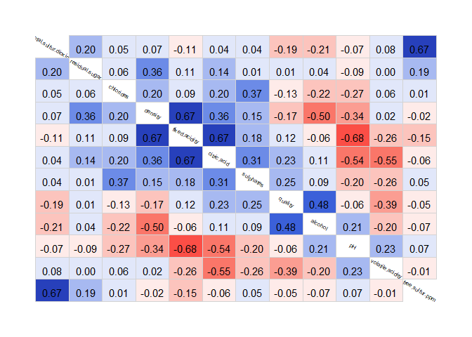

This correlation (Pearson’s) diagram helps identifying the most correlated variables in our dataset. Using the color scheme of blue for positive correlations and red for negative and applying a PCA (principal component analysis) to reorder the variables, it becomes easy to see which variables have a relationship, and how strong it is. A few observations:

- Unsurprisingly, the most correlated variables in the dataset are pH and Fixed Acidity (-0.68) as pH is a scale to measure the overall acidity of liquids. pH is also moderately correlated with citric acid (-0.54). The surprise here is that Volatile Acidity have an small positive effect on pH.
- According to the documentation that came with the dataset, Density should be strongly affected by Alcohol and Residual Sugar. While the first do present an expected “high” negative correlation (for the dataset, it’s more like moderate as far as correlations go), Sugar exhibit a weaker relationship to Density (0.36, along with Citric Acid) than Fixed Acidity (0.67). This last variable actually has the strongest relationship with Density in the dataset.
- Another expected “high” correlated relationship is Total Sulfur Dioxide and Free Sulfur Dioxide (0.67).
- One surprising result is that Volatile Acidity is negatively correlated with Citric Acid (-0.55) and Fixed Acidity (-0.26). What is not surprising is that it has the biggest negative effect on Quality (-0.39) of all the variables, nobody likes wine that tastes like vinegar!
- A strange result is that Sulphates doesn’t appear to be correlated with Total (0.04) and Free Sulfur Dioxide (0.05), as whole point of having it, as it is an additive, is to increase the SO2 levels. One possible explanation for this is that Sulphates are only added to wines with poor naturally occurring levels of SO2, that would explain why Sulphates have a positive effect on Quality (0.25) too.

### Quality

As for Quality, our main variable of interest, a closer look is warranted, here’s the correlations between it and all the variables, ordered from positive to negative:

```
##              alcohol            sulphates          citric.acid
##                 0.48                 0.25                 0.23
##        fixed.acidity       residual.sugar      free.sulfur.ppm
##                 0.12                 0.01                -0.05
##                   pH            chlorides              density
##                -0.06                -0.13                -0.17
## total.sulfur.dioxide     volatile.acidity
##                -0.19                -0.39
```

Here are the r^2 (r-squared) values, this statistic measures how much (in %) a variable explains the other:

```
##              alcohol     volatile.acidity            sulphates
##                23.04                15.21                 6.25
##          citric.acid total.sulfur.dioxide              density
##                 5.29                 3.61                 2.89
##            chlorides        fixed.acidity                   pH
##                 1.69                 1.44                 0.36
##      free.sulfur.ppm       residual.sugar
##                 0.25                 0.01
```

#### Positive

- Alcohol, Sulphates, Citric Acid and Fixed Acidity have a positive correlation with quality. The relationship is weak, with the exception of Alcohol (moderate). This result confirms the findings of the previous analysis. The order of the following plots is from the most positively correlated to the least:

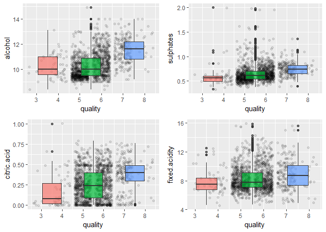

These plots just illustrate what we found out so far. The overlaying box plots represent the bins (best, average and worst wines) created beforehand. I’ve omitted the legends to reduce clutter as they are not necessary with the quality printed on the bottom of each plot.

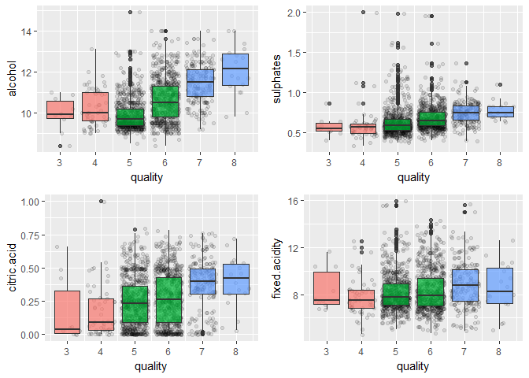

Breaking up the groups, we can see a nice and somewhat linear positive relationship between Quality and Citric Acid, and Quality and Sulphates. Fixed Acidity increases up until Quality = 7, then the median drops slightly, but the interquartile range (IQR) is bigger. Alcohol levels do not increase before we reach Quality = 6, meaning that even the most positively correlated variable can’t save a really bad wine!